# Analysis of contributors to Prosper loan scores by Charles Dellinger

```r
# this was needed for my RStudio install to find pandoc
# pandoc_location <- Sys.getenv("RSTUDIO_PANDOC")
# Sys.setenv(RSTUDIO_PANDOC=as.character(pandoc_location))
```

The data set is about personal loans made through [Prosper Marketplace](https://www.prosper.com). Propser anonymously connects private users who want to lend and borrow money. The marketplace allows users to apply and receive loans from $2,000 to $40,000. During the application process, fairly standard information, like income, occupation, assets, and credit score, is collected. The application information with additionation data about the loan itself, including current state, is what this data set contains. A full list of data collected about each loan is below:

```
##  [1] "AmountDelinquent"
##  [2] "AvailableBankcardCredit"
##  [3] "BankcardUtilization"
##  [4] "BorrowerAPR"
##  [5] "BorrowerRate"
##  [6] "BorrowerState"
##  [7] "ClosedDate"
##  [8] "CreditGrade"
##  [9] "CreditScoreRangeLower"
## [10] "CreditScoreRangeUpper"
## [11] "CurrentCreditLines"
## [12] "CurrentDelinquencies"
## [13] "CurrentlyInGroup"
## [14] "DateCreditPulled"
## [15] "DebtToIncomeRatio"
```

[output cut: 66 more lines]

# Univariate Plots Section

> **Tip**: In this section, you should perform some preliminary exploration of your dataset. Run some summaries of the data and create univariate plots to understand the structure of the individual variables in your dataset. Don’t forget to add a comment after each plot or closely-related group of plots! There should be multiple code chunks and text sections; the first one below is just to help you get started.
- IncomeRange

```
##  Not displayed   Not employed             $0      $1-24,999 $25,000-49,999
##           7741            806            621           7274          32192
## $50,000-74,999 $75,000-99,999      $100,000+
##          31050          16916          17337
```

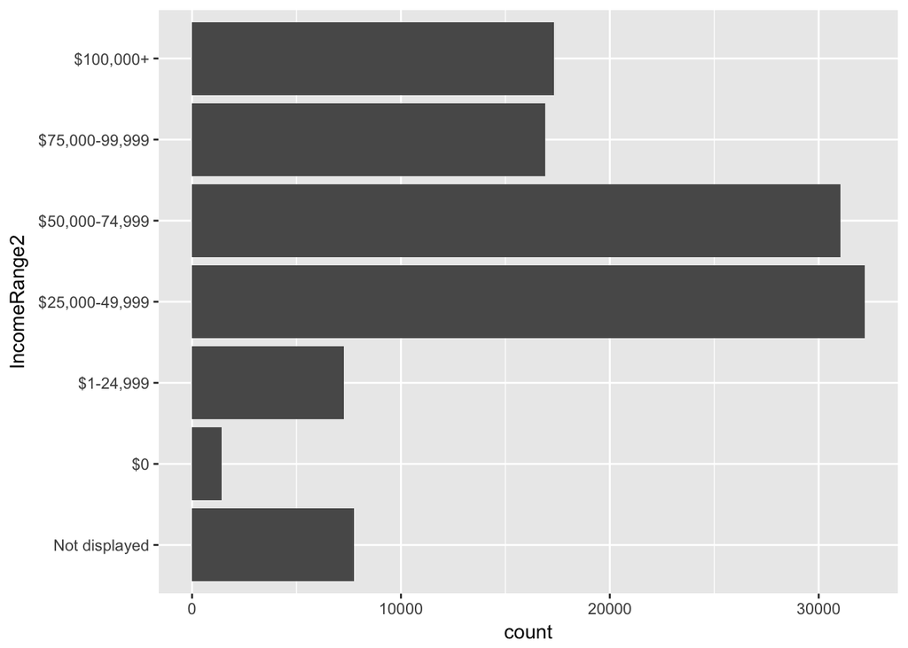

The histogram of IncomeRange shows that most of the borrowers make between $25,000 to $75,000.

- StatedMonthlyIncome

```
##    Min. 1st Qu.  Median    Mean 3rd Qu.    Max.
##       0    3200    4667    5608    6825 1750003
```

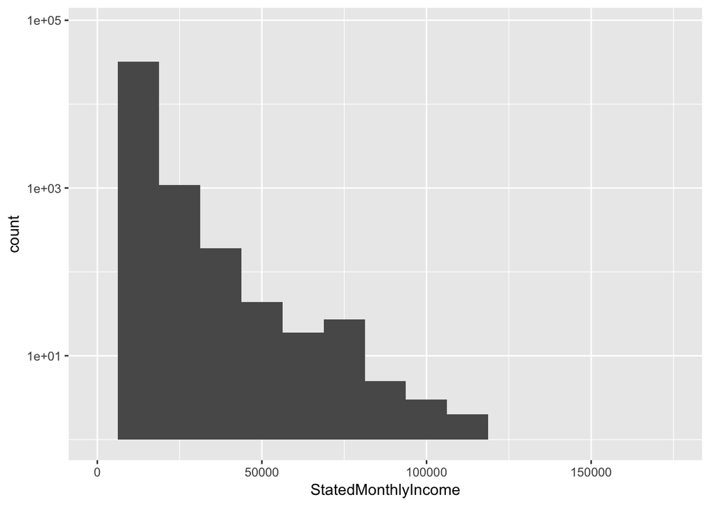

The stated monthly income histogram paints a slightly different picture than the income range bins. The income range bins had more of a bell-curve type shape, whereas the stated income curve looks skewed right.

Will the StatedMonthlyIncome look the same if it is sorted into buckets?

```
##
##            [0,1)      [1,2.5e+04)  [2.5e+04,5e+04)  [5e+04,7.5e+04)
##             1647           111635              564               52
##  [7.5e+04,1e+05) [1e+05,1.75e+06)
##               21               18
```

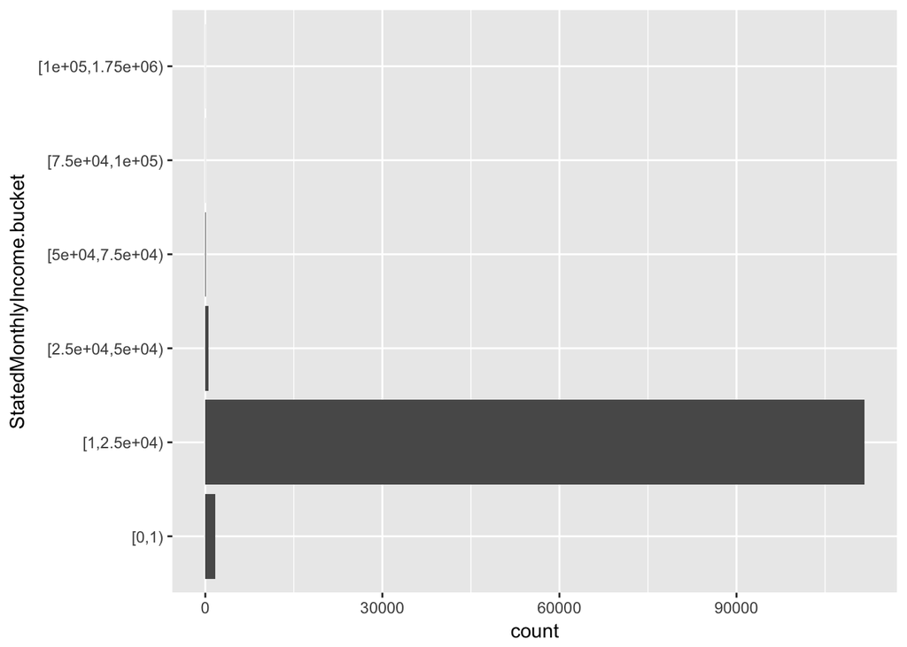

```r
# look at IncomeRange2 counts for comparison
# table(loanData$IncomeRange2)

# look at StatedMonthlyIncome.bucket counts
# table(loanData$StatedMonthlyIncome.bucket)

# check range with a most of the entries and another range
# length(loanData$StatedMonthlyIncome[loanData$StatedMonthlyIncome >= 1 &
#                                     loanData$StatedMonthlyIncome < 25000])
# length(loanData$StatedMonthlyIncome[loanData$StatedMonthlyIncome >= 25000 &
#                                     loanData$StatedMonthlyIncome < 50000])

# everything adds up, so unsure about the difference in ranges
```

The histogram of StatedMonthlyIncome buckets doesn’t seem to align with the income buckets outlined by IncomeRange.

- Occupation

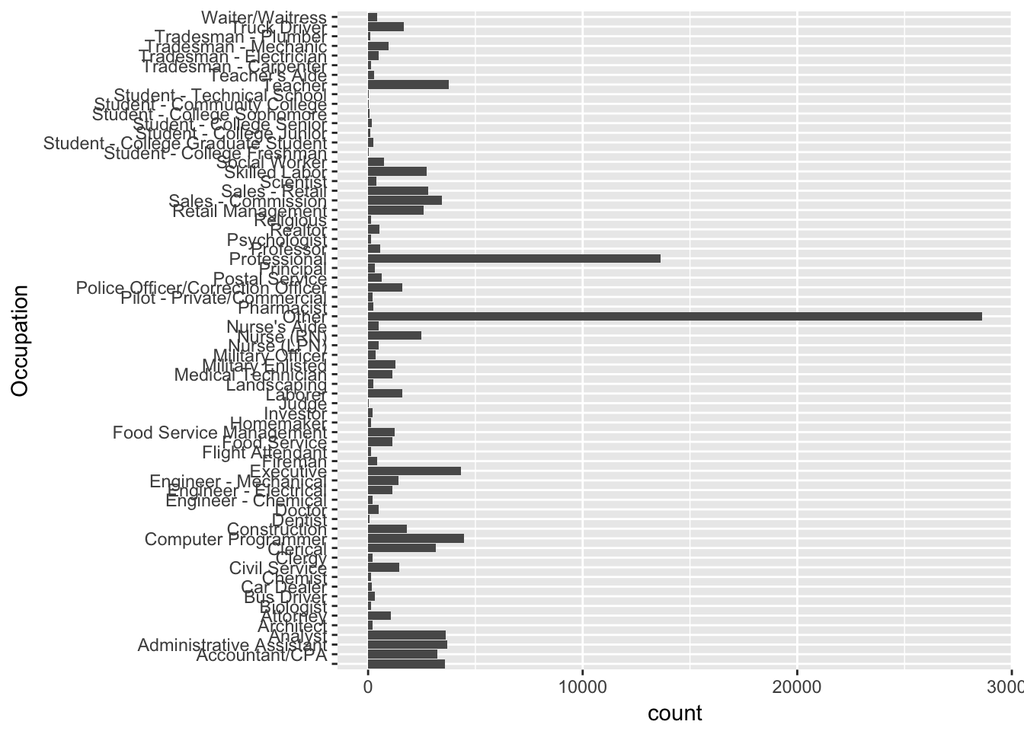

Occupation is going to be pretty useless for categorization as it is since there are so many. Even if grouped, a category like healthcare workers would have different results for instance with a “Nurse’s Aide” versus a “Doctor”. Also, the catch alls of “Other” and “Professional” are ambiguious and seem to dominate; the proportion of Occupation entries:

```
##    Professional           Other Everything Else
##       0.1196100       0.2511651       0.6292249
```

With almost 40% of Occupation entries unusable, the subgroup analysis probably won’t produce generalizable results.

- Debt-to-Income Ratio

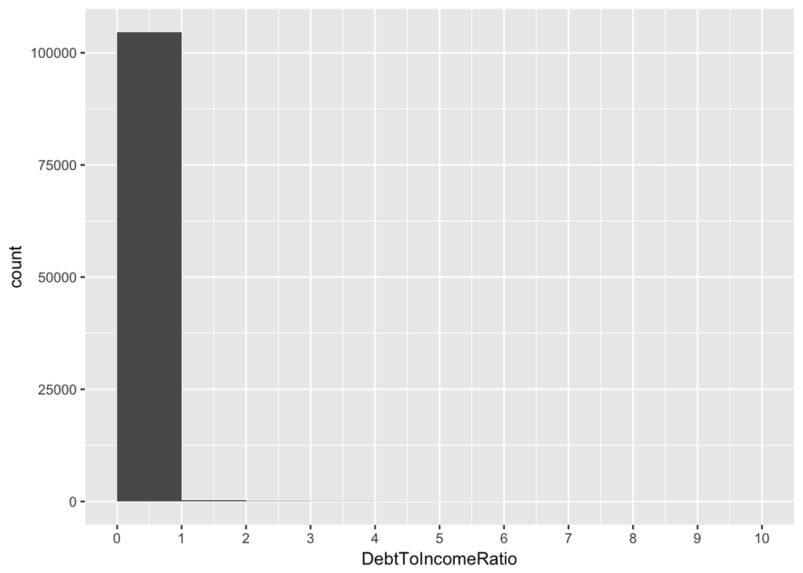

Almost all the debt-to-income ratios are less than 1. People with more debt to pay than their income would have an almost 100% chance of default

```
##   <= 1    > 1
## 104584    799
```

- Delinquencies in the Last 7 Years

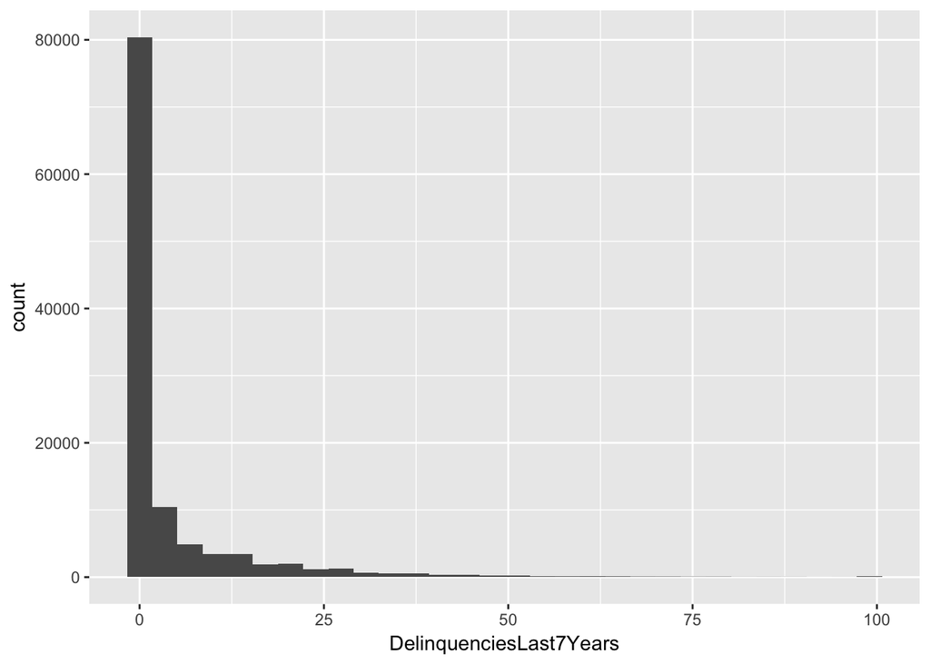

The users applying for loans had a fair number of instances where the payments were late. This metric is a mixed bag for lenders as it would mean that the borrower would accrue interest but also the borower has a higher risk of default.

- Total Trades on the Prosper Platform

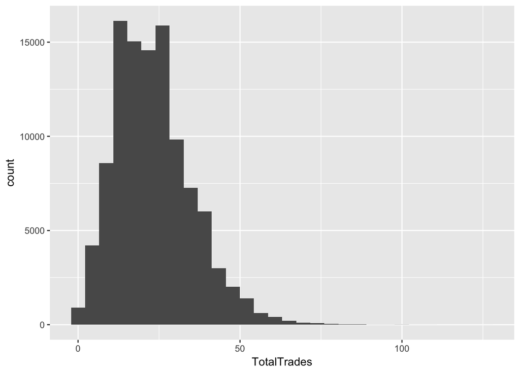

In general, the number of trades is skewed to the right, but the curve between 0 and 50 shows that a lot of borrowers are repeat users.

- Term Length of Loans

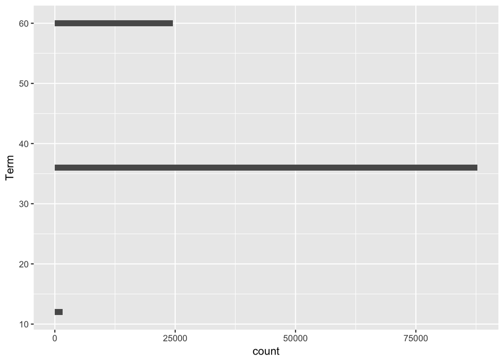

```
##
##    12    36    60
##  1614 87778 24545
```

The data set contains only three loan lengths, which correspond to 1, 3, and 5 years.

- Home Ownership

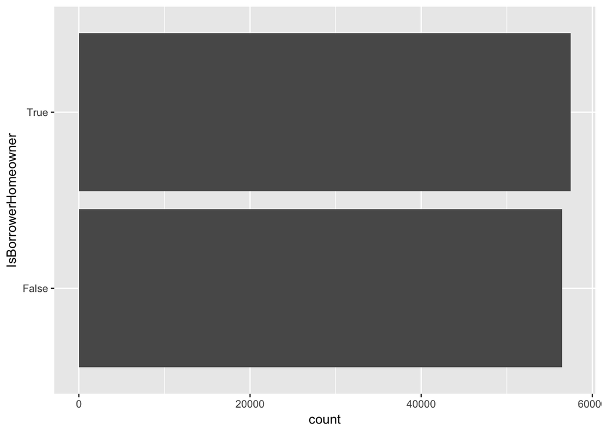

Homeownership would show that a person has an asset, which would make the loan more viable because the borrower can both make payments and has something to borrow against if they need money to meet their liabilities.

This variable might be a good one to use to see split scores or behavior between those that own a home or not.

- BankcardUtilization This variable is strange: “The percentage of available revolving credit that is utilized at the time the credit profile was pulled.” It seems like the amount of available credit that the borrower is utilizing, or home much of the credit card potential have they used.

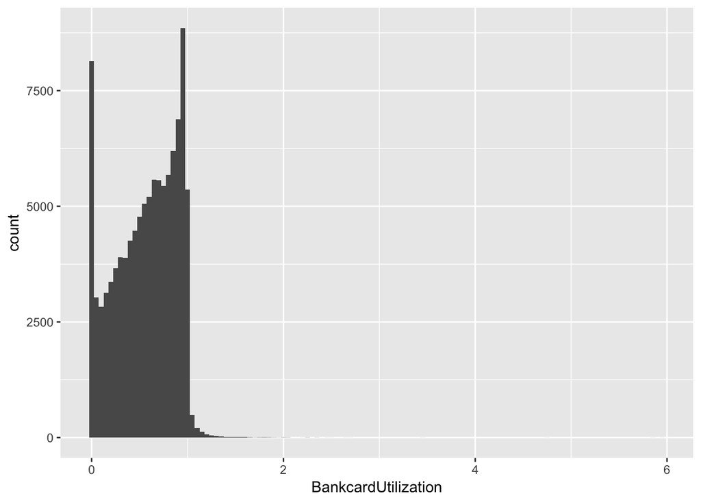

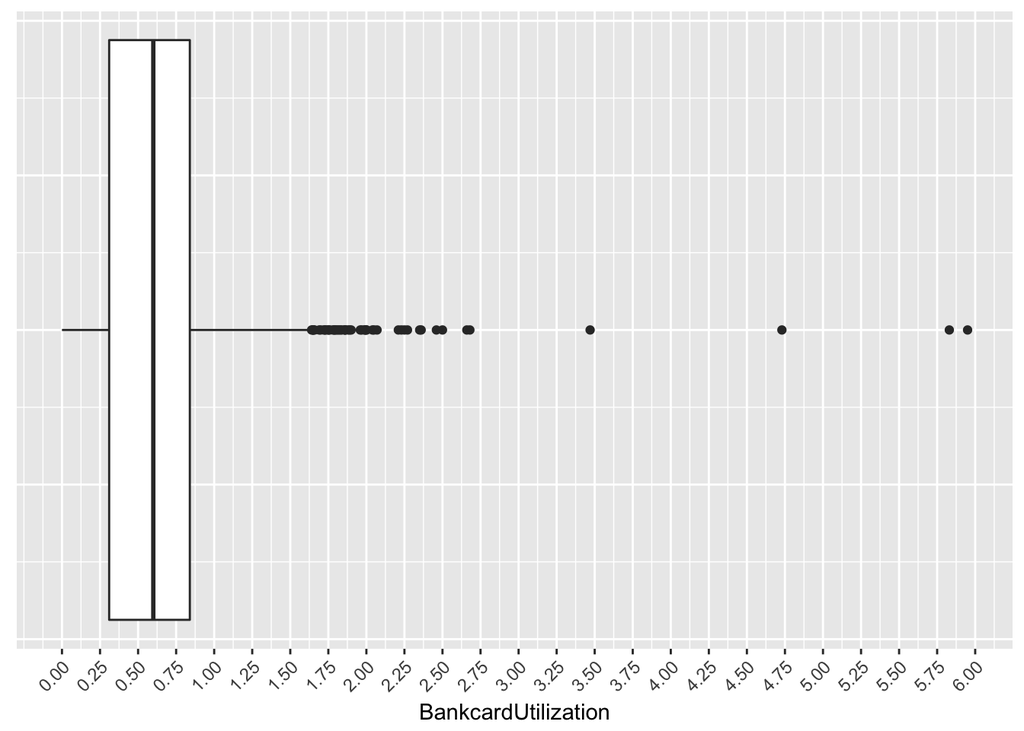

```
##    Min. 1st Qu.  Median    Mean 3rd Qu.    Max.    NA's
##   0.000   0.310   0.600   0.561   0.840   5.950    7604
```

The shape of the bank card utilization histogram shows a spike at 0% and then an increasing trend as the percentage approaches 100%. The box plot show that there are a fair number of people that have somehow overdrafted their bank cards to a pretty high extent. The bank card percentage score would be an interesting metric to test correlations to in the multivariate analysis.

- Credit Score Range

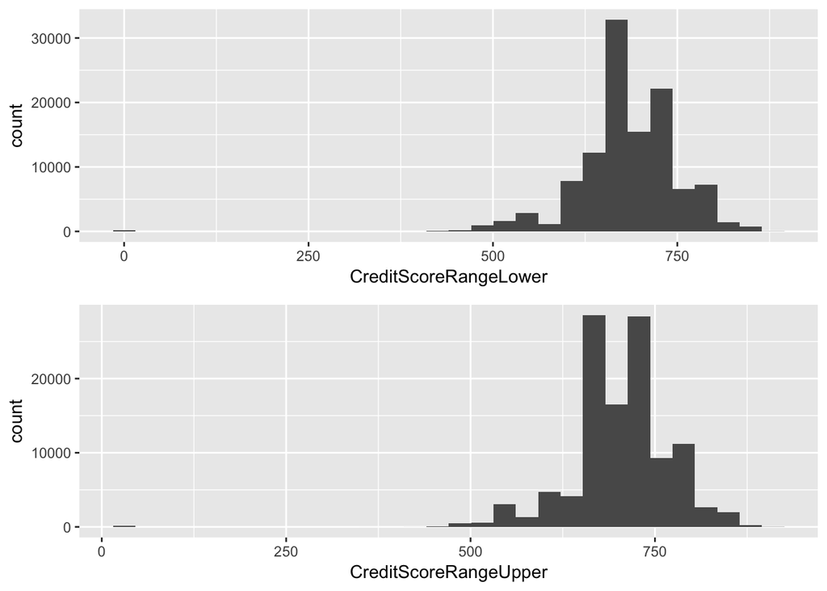

The shapes of the upper and lower credit scores histograms look roughly the same, so I would expect that the ranges are of a standard length of points. A quick graph of the differences will confirm.

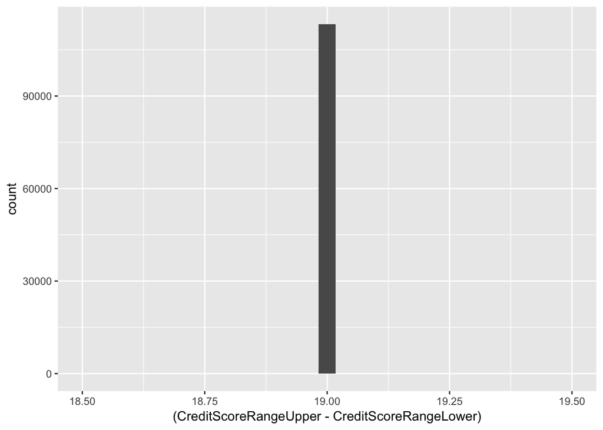

```
##
##     19
## 113346
```

Since the scores are of fixed length, any use of credit scores can use either one to view any trends or make predictions.

- Prosper Score

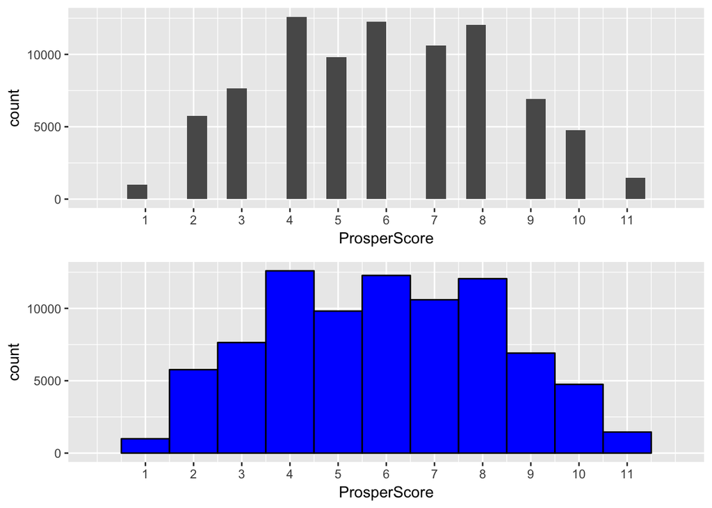

```
##
##     1     2     3     4     5     6     7     8     9    10    11
##   992  5766  7642 12595  9813 12278 10597 12053  6911  4750  1456
```

There seem to be only discrete Prosper scores and for some reason there are score at 11, despite the range in the variable definition file indicating the maximum is 10. Interestingly, the cleaner plot hides the descreteness of the variables.

- Borrower APR

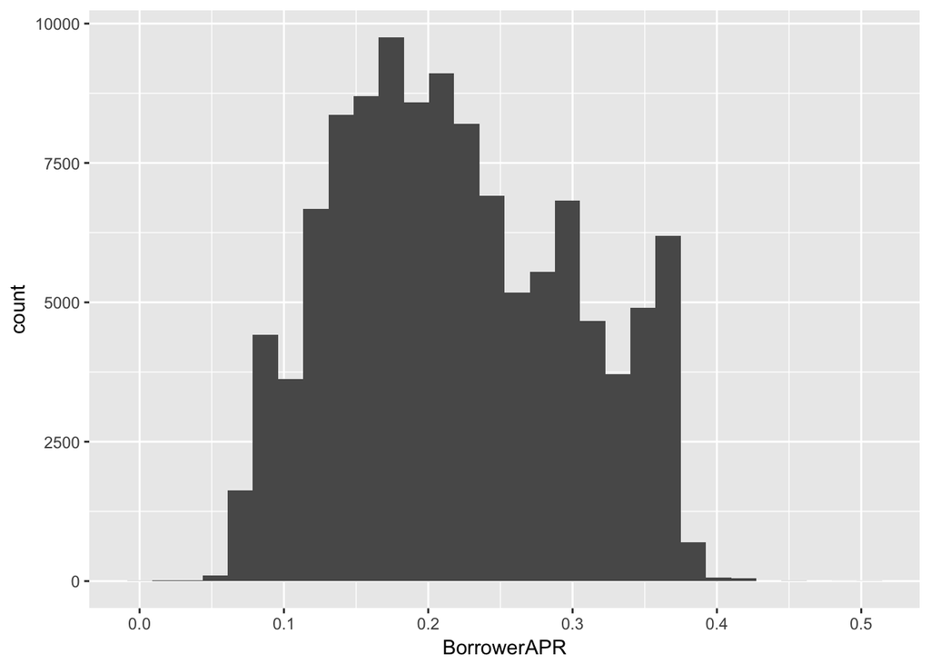

- Loan Amount

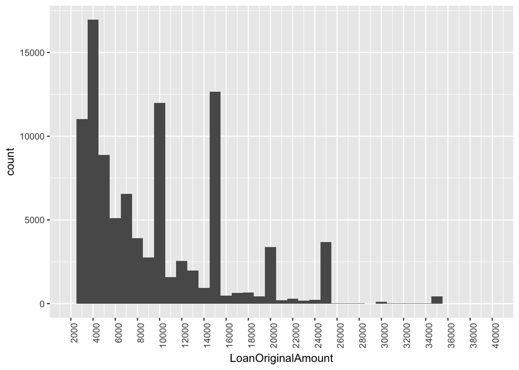

According to the Prosper website, the loans are from $2000 to $40000. Most of the loans are of low value, but there are some clear spikes at higher numbers at 5k intervals ($10000, $15000, $20000, $25000), which shows a bias for people rounding off for their needs.

# Univariate Analysis

### What is the structure of your dataset?

There are 113937 entries, each containing 84 variables of different types.

All of the data categories are related to whether the loan would be a good investment or not, which is presumably wrapped into their proprietary Prosper score.

### What is/are the main feature(s) of interest in your dataset?

The main features of concern are going to be the variables that are commonly primary contributors to risk, such as assets, liabilities, and current state of leverage. Presumably these will be rolled up and reflected in the Prosper score (“ProsperScore”). The following are a listing of those variables: “IncomeRange”, “DebtToIncomeRatio”, “DelinquenciesLast7Years”, “TotalTrades”, “Term”, “IsBorrowerHomeowner”, “BankcardUtilization”, “BorrowerAPR”, “LoanOriginalAmount”, “CreditScoreRangeLower”/“CreditScoreRangeUpper”

investigation into your feature(s) of interest? Additional features that might build a richer picture would include: “ListingCategory..numeric.” - to see what the loan is for “LoanStatus” - to check on overdue loans “Investors” - how many people have confidence that the borrower will pay? “Recommentations” - how many people vouch for the borrower? “EmploymentStatusDuration” - is the borrower’s cashflow consistent? “Occupation” - this might have an influence, but the categories are questionable

### Did you create any new variables from existing variables in the dataset?

I created IncomeRange2 and StatedMonthlyIncome.bucket: * IncomeRange2 - consolidates “Not employed” to have an income of $0 * StatedMonthlyIncome.bucket - bucketed the StatedMonthlyIncome to test against IncomeRange, but the results made it seem like the monthly income wasn’t as reliable.

### Of the features you investigated, were there any unusual distributions?

Did you perform any operations on the data to tidy, adjust, or change the form  
of the data? If so, why did you do this?

All the data were skewed appropriately or of a normalized scoring. The exceptions to a lot of distributions were around even number intervals, because people round their expectation needs.

There were some strange things within some of the variables. The Prosper score had scores of 11 even though the range was stated to be 1-10. There were bankcard utilizations and debt-to-income ratios that were questionable, because the borrower had much greater debt than they could pay, like the borrower that had almost 600% bankcard utilization and the 799 borrowers that had more debt payments per month than their monthly income.

# Bivariate Plots Section

# Bivariate Analysis

# Multivariate Plots Section

# Multivariate Analysis

# Final Plots and Summary

# Reflection

# References

[RStudio cheatsheet](https://www.rstudio.com/wp-content/uploads/2015/02/rmarkdown-cheatsheet.pdf) [RStudio cheatsheet 2.0](https://www.rstudio.com/wp-content/uploads/2016/03/rmarkdown-cheatsheet-2.0.pdf) [StackOverflow: Rotating and spacing axis labels in ggplot2](https://stackoverflow.com/questions/1330989/rotating-and-spacing-axis-labels-in-ggplot2?utm_medium=organic&utm_source=google_rich_qa&utm_campaign=google_rich_qa) [Debt to Income Ratio](https://www.consumerfinance.gov/ask-cfpb/what-is-a-debt-to-income-ratio-why-is-the-43-debt-to-income-ratio-important-en-1791/) [Remove all of x axis labels in ggplot (duplicate)](https://stackoverflow.com/questions/35090883/remove-all-of-x-axis-labels-in-ggplot?utm_medium=organic&utm_source=google_rich_qa&utm_campaign=google_rich_qa)